# Lung Cancer Survival Analysis

Daniel Mon, Nhi Nguyen, Ethan Gandiboyina, Sean Paulo

2024-12-14

- In this R markdown we will explain survival analysis in the context of the lung cancer dataset which is included in the survival package in R.*

Survival analysis is a statistical method used to model and analyze the time until an event of interest occurs on a given subject. Commonly applied in medical research, it was initially developed to evaluate the efficacy of drugs and treatments. In this context, the “event” often refers to patient outcomes such as death or recovery over a specified observation period.Hence, the name “Survival Analysis”.

In this report we will…

Use the Kaplin Meier to: - estimate and plot survival functions - extract survival data - compare survival curves for both sexes and weight loss patients Use cox model to: - determine the log hazard of variables - form regression models to predict survivability of a patient.

```r
knitr::opts_chunk$set(echo = TRUE, fig.height = 6, fig.width = 8)
options(repos = c(CRAN = "https://cloud.r-project.org"))
if (!require("survival")) install.packages("survival")
if (!require("ggplot2")) install.packages("ggplot2")
if (!require("ggsurvfit")) install.packages("ggsurvfit")
if (!require("gtsummary")) install.packages("gtsummary")
if (!require("tibble")) install.packages("tibble")
if (!require("lubridate")) install.packages("lubridate")
```

### **1. Methods & Tools**

#### **1.1 Dataset Description**

The lung data set contains data on 228 patients, including survival time, censoring status, and several clinical and demographic variables such as age, sex, ECOG performance score, and weight loss.

#### **1.2 Installation and Loading Libraries**

```r
# Load libraries
library(survival)
library(ggplot2)
library(dplyr)
library(ggsurvfit)
library(survminer)
library(gtsummary)
library(tibble)
library(lubridate)
library(devtools)
library(condsurv)
library(ezfun)

# Set contrast palette for plots
ezfun::set_ccf_palette("contrast")
```

```
## <environment: R_GlobalEnv>
```

```r
rm(lung)
```

#### **1.3 Data Preprocessing**

```r
# Load the lung cancer dataset
lung_cancer_df <- lung

# Recode the `status` variable: 1 = censored, 2 = dead
lung_cancer_df <- lung_cancer_df %>% mutate(
    status = recode(status, `1` = 0, `2` = 1)
)

# Preview the dataset
head(lung_cancer_df)
```

```
##   inst time status age sex ph.ecog ph.karno pat.karno meal.cal wt.loss
## 1    3  306      1  74   1       1       90       100     1175      NA
## 2    3  455      1  68   1       0       90        90     1225      15
## 3    3 1010      0  56   1       0       90        90       NA      15
## 4    5  210      1  57   1       1       90        60     1150      11
## 5    1  883      1  60   1       0      100        90       NA       0
## 6   12 1022      0  74   1       1       50        80      513       0
```

### **2. Results/Findings**

#### **2.1 Kaplan-Meier Survival Analysis**

One of the most basic forms of Survival analysis is plotting the survivors over a given time on a graph. The formula to do so is given by: $S(t) = P(T > t)$. This is calculated for each point in time. When performing this plotting using real world data we are often presented with the issue of censoring. Due to missing data we cannot accurately calculate the survival curve. As a result, we must approximate the Survival curve using the Kaplan Meier Estimate. This is given by using the formula:
$$S(t) = \prod_{i: t_i \leq t} \left( 1 -
\frac{d_i}{n_i} \right)$$

Using the Kaplan Meier estimate we can plot a survival curve for the lung cancer dataset.

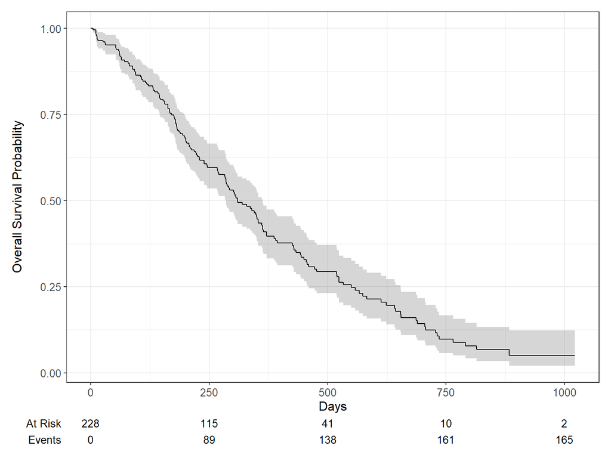

```r
# Kaplan-Meier curve
survfit2(Surv(time, status) ~ 1, data = lung_cancer_df) %>%
  ggsurvfit() +
  labs(
    x = "Days",
    y = "Overall Survival Probability"
  ) +
  add_confidence_interval() +
  add_risktable()
```

Using The Kaplan Meier Curve plotted above we can determine the proportion of people who survived until a given time (t).

#### **2.2 Kaplan-Meier Survival by Sex**

Additionally, we can use produce several Kaplan-Meier curves to plot the survival curves of different groups. The Kaplan-Meier survival curve below is stratified by sex to explore differences in survival probabilities between the Male and Female.

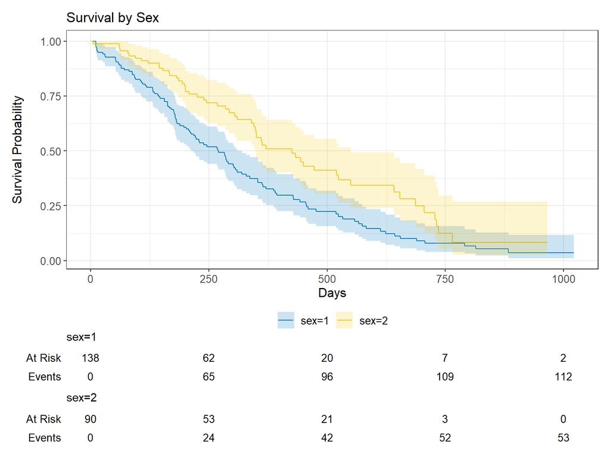

```r
# Kaplan-Meier curve stratified by sex
survfit(Surv(time, status) ~ sex, data = lung_cancer_df) %>%
  ggsurvfit() +
  labs(
    x = "Days",
    y = "Survival Probability",
    title = "Survival by Sex"
  ) +
  add_confidence_interval() +
  add_risktable()
```

**Findings:** - **Males:** Median survival is approximately **270 days**. - **Females:** Median survival is approximately **426 days**. - Females demonstrate a significantly higher survival probability compared to males.

#### **2.3 Median Survival**

```r
# Median survival time
lung_cancer_df %>%
  filter(status == 1) %>%
  summarize(median_surv = median(time))
```

```
##   median_surv
## 1         226
```

```r
# Median survival by sex
lung_cancer_df %>%
  group_by(sex) %>%
  summarize(median_surv = median(time))
```

```
## # A tibble: 2 × 2
##     sex median_surv
##   <dbl>       <dbl>
## 1     1        224
## 2     2        292.
```

#### **2.4 Survival by ECOG Performance Score**

The survival function can also be plotted for other factored variables, for instance the ph.ecog variable. The *ph.ecog** variable represents the ECOG score of a patient, this measures a patients physical capabilities. The ECOG value ranges between 0 and 4 where 0=fully active, and 4=confined to a bed.

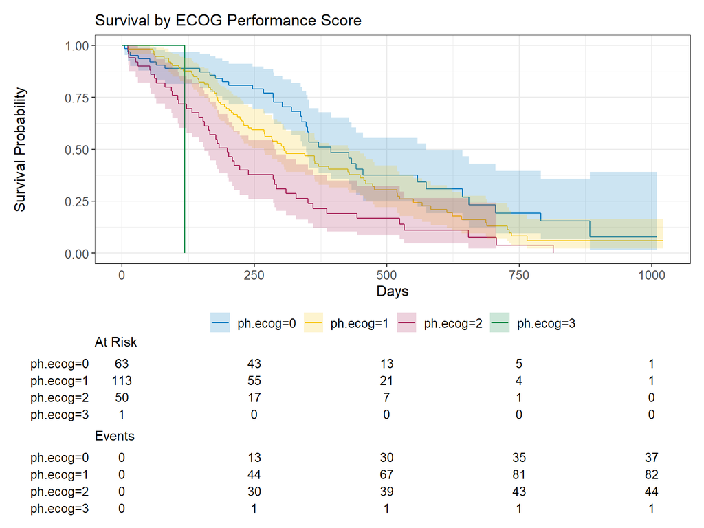

```r
# Kaplan-Meier curve stratified by ECOG score
survfit(Surv(time, status) ~ ph.ecog, data = lung_cancer_df) %>%
  ggsurvfit() +
  labs(
    x = "Days",
    y = "Survival Probability",
    title = "Survival by ECOG Performance Score"
  ) +
  add_confidence_interval() +
  add_risktable()
```

#### **2.5 Survival by Weight Loss**

Similarly, we can see how patients’ weight loss can influence survival.

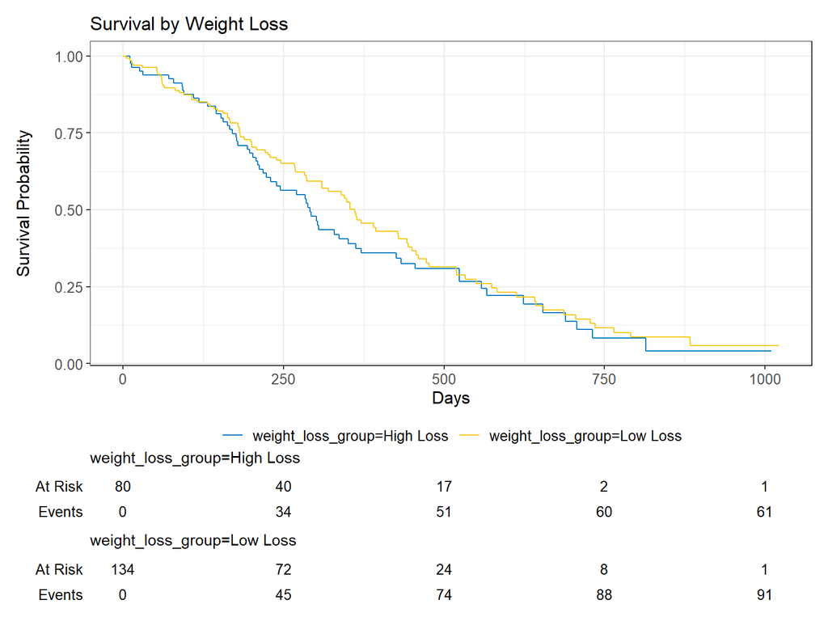

```r
# Create weight loss group
lung_cancer_df <- lung_cancer_df %>%
  mutate(weight_loss_group = if_else(wt.loss > 10, "High Loss", "Low Loss"))

# Kaplan-Meier curve stratified by weight loss
survfit(Surv(time, status) ~ weight_loss_group, data = lung_cancer_df) %>%
  ggsurvfit() +
  labs(
    x = "Days",
    y = "Survival Probability",
    title = "Survival by Weight Loss"
  ) +
  add_risktable()
```

#### **2.6 Cox Proportional Hazards Model**

The cox regression model is a semi-parametric model(we dont assume a distribution for $h_0(t)$) used to fit uni/multi variable regression models to survival outcomes. This allows us to view how specific factors influence event rate at a given time (Hazard rate). The Cox model is given by using the hazard function:
$$h(t | X) = h_0(t) \exp(\beta_1 X_1 +
\beta_2 X_2 + \dots + \beta_p X_p)$$
h(t| X)= Hazard at time t for a given variable $h_0(t)$= baseline hazard function exp(…) exponential linear combination of variables. Using the cox model we are able to determine the significance of each variable in determining their hazard ratio(hazard ratio describes the likelihood a variable has on the event), and produce a model to predict hazard of a patient.

```r
# Cox proportional hazards model
cox_model <- coxph(Surv(time, status) ~ ., data = lung_cancer_df)
cox_model %>% tbl_regression(exp = TRUE)
```

| **Characteristic** | **HR**<sup>1</sup> | **95% CI**<sup>1</sup> | **p-value** |
| --- | --- | --- | --- |
| inst | 0.97 | 0.95, 1.00 | 0.029 |
| age | 1.01 | 0.99, 1.04 | 0.3 |
| sex | 0.57 | 0.38, 0.85 | 0.006 |
| ph.ecog | 2.44 | 1.52, 3.93 | <0.001 |
| ph.karno | 1.03 | 1.00, 1.05 | 0.023 |
| pat.karno | 0.99 | 0.97, 1.00 | 0.2 |
| meal.cal | 1.00 | 1.00, 1.00 | >0.9 |
| wt.loss | 0.98 | 0.96, 1.00 | 0.11 |
| weight_loss_group |  |  |  |
| High Loss | — | — |  |
| Low Loss | 0.88 | 0.46, 1.70 | 0.7 |

<sup>1</sup> HR = Hazard Ratio, CI = Confidence Interval

In the table above we can determine that variables: inst,sex,ph.ecog, and ph.karno are significant in predicting survival time. So we can remake the model using those variables only.

```r
cox_model <- coxph(Surv(time, status) ~ inst + sex + ph.ecog + ph.karno, data = lung_cancer_df)

#cox_model %>% tbl_regression(exp = TRUE)
summary_df<-summary(cox_model)
summary(cox_model)
```

```
## Call:
## coxph(formula = Surv(time, status) ~ inst + sex + ph.ecog + ph.karno,
##     data = lung_cancer_df)
##
##   n= 225, number of events= 162
##    (3 observations deleted due to missingness)
##
##               coef exp(coef)  se(coef)      z Pr(>|z|)
## inst     -0.023017  0.977246  0.011067 -2.080  0.03755 *
## sex      -0.555693  0.573674  0.169378 -3.281  0.00104 **
## ph.ecog   0.727964  2.070861  0.186299  3.907 9.33e-05 ***
## ph.karno  0.012754  1.012836  0.009689  1.316  0.18807
## ---
## Signif. codes:  0 '***' 0.001 '**' 0.01 '*' 0.05 '.' 0.1 ' ' 1
##
##          exp(coef) exp(-coef) lower .95 upper .95
## inst        0.9772     1.0233    0.9563    0.9987
## sex         0.5737     1.7431    0.4116    0.7995
## ph.ecog     2.0709     0.4829    1.4374    2.9835
## ph.karno    1.0128     0.9873    0.9938    1.0323
##
## Concordance= 0.643  (se = 0.026 )
## Likelihood ratio test= 33.78  on 4 df,   p=8e-07
## Wald test            = 33.25  on 4 df,   p=1e-06
## Score (logrank) test = 33.58  on 4 df,   p=9e-07
```

The summary of the model gives the coefficients to describe the hazard function of the lung cancer patients depending on their inst,sex,ph.ecog, and ph.karno . Using these values we can model survival functions for different combinations of variables. Plotting functions for each variable would be very messy so we can make a cox model plotting hazard of 2 institutions and gender.

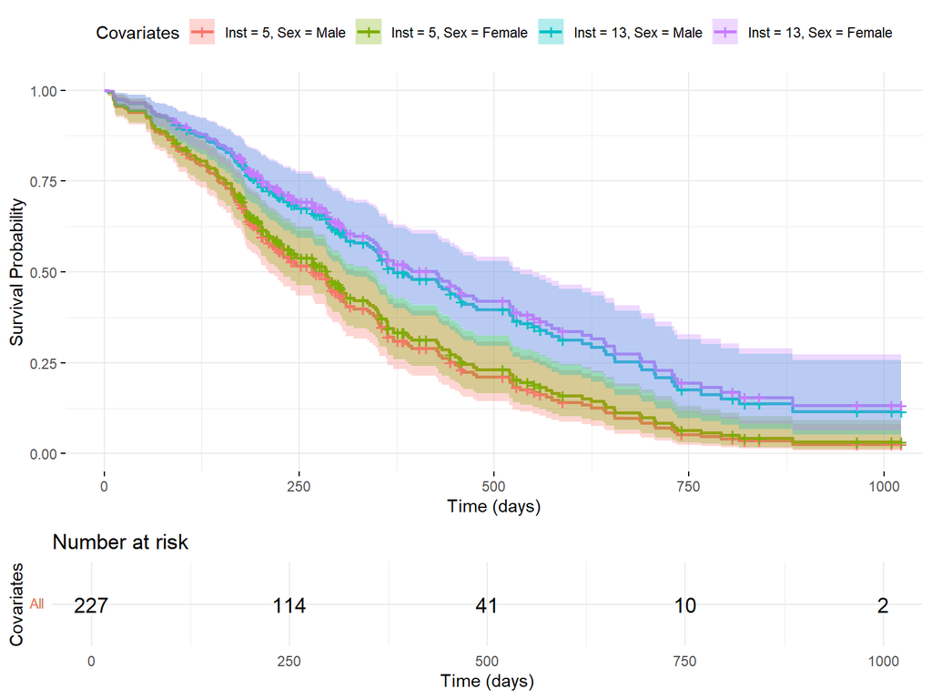

```r
# Randomly select two institutions
set.seed(551)
selected_institutions <- sample(unique(lung$inst), 2)

# Fit the Cox model
cox_model <- coxph(Surv(time, status) ~ inst + sex, data = lung)

# Create new data for the selected institutions and both genders
new_data <- expand.grid(
  inst = selected_institutions,
  sex = c(1, 2)  # 1 = Male, 2 = Female
)

# Generate survival curves using survfit
surv_fit <- survfit(cox_model, newdata = new_data)

# Plot the survival curves with ggsurvplot
ggsurvplot(
  surv_fit,
  data = lung,
  risk.table = TRUE,
  pval = TRUE,
  conf.int = TRUE,
  ggtheme = theme_minimal(),
  xlab = "Time (days)",
  ylab = "Survival Probability",
  legend.title = "Covariates",
  legend.labs = paste0("Inst = ", rep(selected_institutions, each = 2),
                       ", Sex = ", rep(c("Male", "Female"), times = 2)) # Custom legend
)
```

#### **2.7 Stratified Survival Probabilities**

```r
# Summary of survival probabilities
summary(survfit(Surv(time, status) ~ sex, data = lung_cancer_df), times = c(180, 365))
```

```
## Call: survfit(formula = Surv(time, status) ~ sex, data = lung_cancer_df)
##
##                 sex=1
##  time n.risk n.event survival std.err lower 95% CI upper 95% CI
##   180     89      49    0.644  0.0408        0.569        0.730
##   365     35      36    0.336  0.0434        0.261        0.433
##
##                 sex=2
##  time n.risk n.event survival std.err lower 95% CI upper 95% CI
##   180     71      14    0.842  0.0387        0.770        0.922
##   365     30      22    0.526  0.0597        0.421        0.658
```